# MTH6139 Time Series

Palantir Technologies Stock Price Forecasting

Ares Visoka

Spring term 2026

# Introduction

This project analyses the monthly share price of Palantir Technologies Inc.(PLTR), a data software company that develops data integration and analytics platforms. I used Meta’s Prophet forecasting system to model the trend in the monthly adjusted closing price and produce a 12-month forecast.

# Loading the data

```r
library(tseries)
library(prophet)
library(zoo)
```

- The library section loads the packages `tseries` for downloading the data, `prophet` for the forecasting model and `zoo` for handling dates

```r
palantir <- get.hist.quote("PLTR", quote = "AdjClose")
```

```
## time series starts 2020-09-30
## time series ends   2026-03-17
```

- Used to download the history of Palantir’s adjusted closing price from Yahoo Finance

```r
palantir_raw <- data.frame(
    date = as.Date(time(palantir)),
    price = as.numeric(palantir)
)
```

- Used to convert the downloaded data into a table of columns (date and price)

```r
palantir_raw$month <- as.yearmon(palantir_raw$date)
palantir_monthly <- aggregate(price ~ month, data = palantir_raw, FUN = mean)
```

- Sorts the daily price by month and calculates the monthly average

```r
palantir_df <- data.frame(
    ds = as.Date(palantir_monthly$month),
    y = palantir_monthly$price
)
```

- Creates a data frame with column names `ds` and `y` as this is the formatting required for the Prophet model. Column `ds` corresponds to the date and column `y` corresponds to price

```r
head(palantir_df)
```

```
##           ds         y
## 1 2020-09-01  9.500000
## 2 2020-10-01  9.804545
## 3 2020-11-01 17.498500
## 4 2020-12-01 26.326364
## 5 2021-01-01 28.570527
## 6 2021-02-01 30.308947
```

- Used to check if the data loaded correctly

# Data analysis

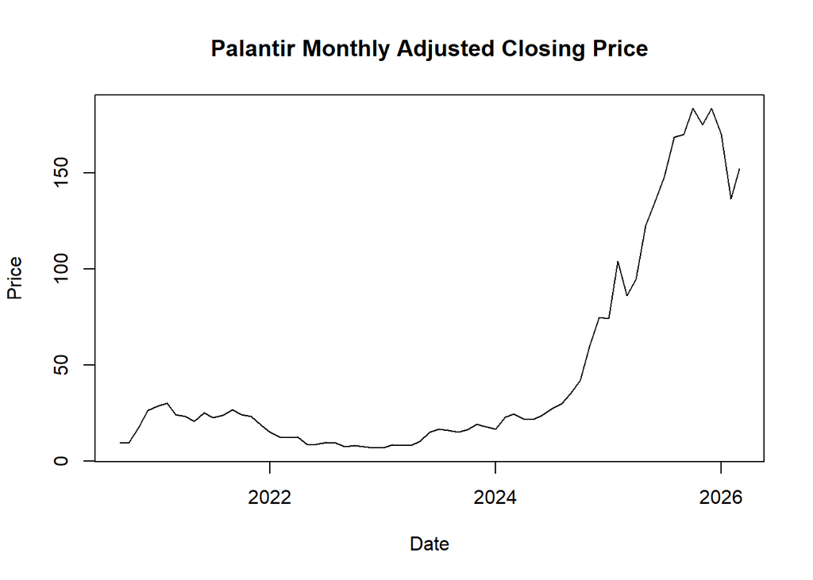

```r
plot(palantir_df$ds, palantir_df$y, type = "l",
     main = "Palantir Monthly Adjusted Closing Price",
     xlab = "Date",
     ylab = "Price")
```

- Creates a visual by plotting the monthly price over time

The series shows a massive increase in price after 2024 due to the rise in use of artificial intelligence and governmental contracts with the US and the UK.

```r
summary(palantir_df$y)
```

```
##    Min. 1st Qu.  Median    Mean 3rd Qu.    Max.
##   6.843  12.527  22.941  46.843  50.688 183.519
```

```r
sd(palantir_df$y)
```

```
## [1] 54.47375
```

- Prints the `minimum`, `quartiles`, `median`, `maximum`, `mean` and `standard deviation`

# Fitting Prophet

```r
palantirModel <- prophet(palantir_df)
```

- Used to fit the Prophet model to the data

```r
palantirFuture <- make_future_dataframe(palantirModel, periods = 12, freq = "month")
```

- Used to create a data frame of the next 12 months for the Prophet model to create a forecast

```r
palantirForecast <- predict(palantirModel, palantirFuture)
head(palantirForecast)
```

```
##           ds    trend additive_terms additive_terms_lower additive_terms_upper
## 1 2020-09-01 18.04722     -0.3757150           -0.3757150           -0.3757150
## 2 2020-10-01 17.92270     -0.3511549           -0.3511549           -0.3511549
## 3 2020-11-01 17.79403      1.3628585            1.3628585            1.3628585
## 4 2020-12-01 17.66951      6.0874939            6.0874939            6.0874939
## 5 2021-01-01 17.54084     -1.6249639           -1.6249639           -1.6249639
## 6 2021-02-01 17.41217     -3.0945356           -3.0945356           -3.0945356
##       yearly yearly_lower yearly_upper multiplicative_terms
## 1 -0.3757150   -0.3757150   -0.3757150                    0
## 2 -0.3511549   -0.3511549   -0.3511549                    0
## 3  1.3628585    1.3628585    1.3628585                    0
## 4  6.0874939    6.0874939    6.0874939                    0
## 5 -1.6249639   -1.6249639   -1.6249639                    0
## 6 -3.0945356   -3.0945356   -3.0945356                    0
##   multiplicative_terms_lower multiplicative_terms_upper yhat_lower yhat_upper
## 1                          0                          0  2.1293722   33.38522
## 2                          0                          0  1.1748384   34.18722
## 3                          0                          0  3.7508421   37.19463
## 4                          0                          0  6.4348336   40.72785
## 5                          0                          0  0.3394138   33.76168
## 6                          0                          0 -1.7682136   30.08972
##   trend_lower trend_upper     yhat
## 1    18.04722    18.04722 17.67151
## 2    17.92270    17.92270 17.57155
## 3    17.79403    17.79403 19.15689
## 4    17.66951    17.66951 23.75700
## 5    17.54084    17.54084 15.91588
## 6    17.41217    17.41217 14.31763
```

# Results

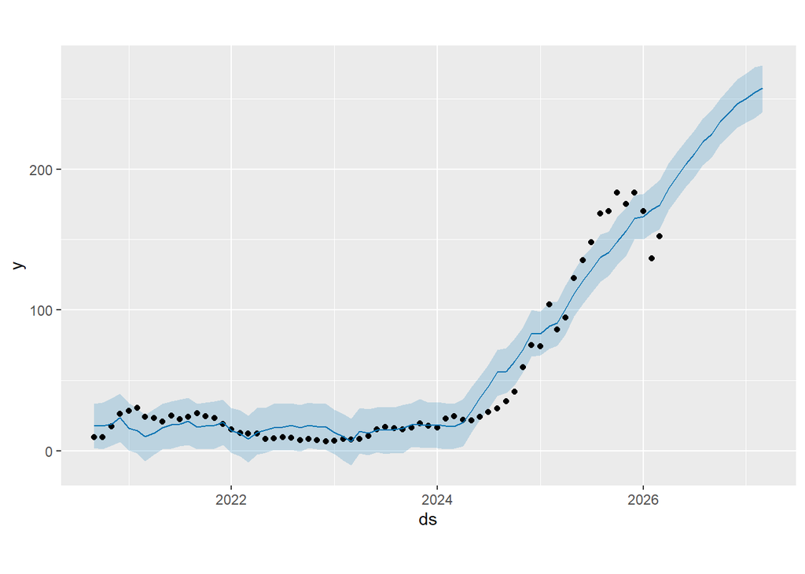

```r
plot(palantirModel, palantirForecast)
```

- Plots the historical data alongside the forecast and uncertainty interval

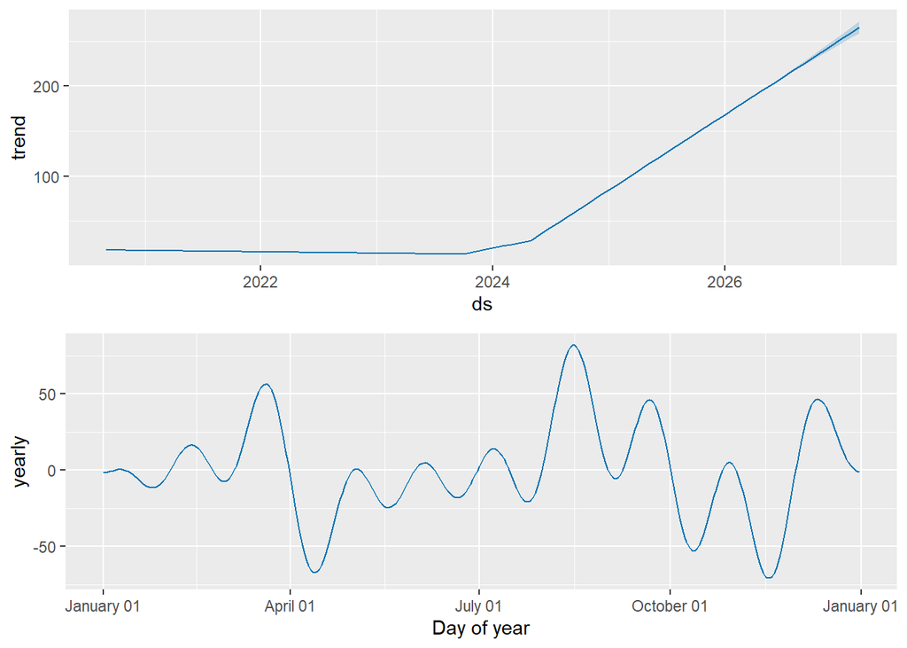

```r
prophet_plot_components(palantirModel, palantirForecast)
```

- Separates the forecast into trend and yearly seasonality

# Conclusion

Prophet models the Palantir monthly price series well, capturing the strong upward trend and seasonal variation. A key limitation is that stock prices are heavily influenced by news, economic data, investor sentiment along with other factors which a statistical model can’t take into account and anticipate.

# References

- Meta Prophet documentation: https://facebook.github.io/prophet/docs/quick_start.html
- Yahoo Finance: https://finance.yahoo.com/quote/PLTR/
- RStudio: https://rmarkdown.rstudio.com/lesson-1.html
- Data-camp course: https://www.datacamp.com/courses/reporting-with-rmarkdown